# Finite State Markov Chains

## 7.4 Julia Implementation

### 7.4.1 Counting Transitions

Let us write a function that counts the number of transitions between each pair of states:

```julia
"""
    countTransitions(s, n_states)

Count the number of transitions between each pair of states in a state sequence.

# Arguments
- `s`: a vector of state indices (integers from 1 to `n_states`)
- `n_states`: the number of distinct states

# Returns
- An `n_states × n_states` matrix `N` where `N[i,j]` is the number of transitions from state `i` to state `j`
"""
function countTransitions(s, n_states)
    N = zeros(Int, n_states, n_states)   # Initialize count matrix
    for t in 2:length(s)
        N[s[t-1], s[t]] += 1            # Increment the (i,j) count
    end
    return N
end
```

```
Main.Notebook.countTransitions
```

The function loops through the state sequence and, for each consecutive pair $(s_{t-1}, s_t)$, increments the corresponding entry in the count matrix.

### 7.4.2 Estimating the Transition Matrix

To go from counts to probabilities, we normalize each row by its sum:

```julia
"""
    estimateTransitionMatrix(s, n_states)

Estimate a transition matrix from a state sequence using maximum likelihood.

# Arguments
- `s`: a vector of state indices (integers from 1 to `n_states`)
- `n_states`: the number of distinct states

# Returns
- An `n_states × n_states` transition matrix where entry `(i,j)` is the MLE estimate of the probability of transitioning from state `i` to state `j`
"""
function estimateTransitionMatrix(s, n_states)
    N = countTransitions(s, n_states)
    P̂ = N ./ sum(N, dims=2)              # Divide each row by its sum
    return P̂
end
```

```
Main.Notebook.estimateTransitionMatrix
```

The expression `sum(N, dims=2)` sums along dimension 2 (columns), producing a column vector of row totals. Broadcasting with `./` then divides each element by its row total.

### 7.4.3 Testing on Simulated Data

Let us test our estimator on the simulated business cycle data from earlier. Recall that we generated $T = 5{,}000$ observations from a Markov chain with the true transition matrix:

```julia
P
```

```
2×2 Matrix{Float64}:
 0.9  0.1
 0.3  0.7
```

Applying our estimator to the simulated state sequence:

```julia
P̂ = estimateTransitionMatrix(s, 2)
```

```
2×2 Matrix{Float64}:
 0.899678  0.100322
 0.294256  0.705744
```

We can compare the estimate to the truth:

```julia
println("True P:")
display(P)
println("\nEstimated P̂:")
display(P̂)
println("\nDifference (P̂ - P):")
display(round.(P̂ .- P, digits=4))
```

```
True P:

Estimated P̂:

Difference (P̂ - P):
```

```
2×2 Matrix{Float64}:
 0.9  0.1
 0.3  0.7
```

```
2×2 Matrix{Float64}:
 0.899678  0.100322
 0.294256  0.705744
```

```
2×2 Matrix{Float64}:
 -0.0003  0.0003
 -0.0057  0.0057
```

The differences should be small—on the order of a few percentage points or less—confirming that the MLE works well even with a moderately sized sample.

### 7.4.4 How Sample Size Affects Accuracy

To see how estimation accuracy improves with more data, we can estimate the transition matrix from simulations of different lengths and track the maximum absolute error:

```julia
sample_sizes = [50, 200, 1000, 5000, 20000]

errors = map(sample_sizes) do T_sim
    s_sim, _ = simulateMarkov(P, ḡ, T_sim)
    P̂_sim = estimateTransitionMatrix(s_sim, 2)
    return maximum(abs.(P̂_sim .- P))   # Max absolute error across all entries
end

hcat(sample_sizes, round.(errors, digits=4))
```

```
5×2 Matrix{Float64}:
    50.0  0.0273
   200.0  0.1412
  1000.0  0.0234
  5000.0  0.0173
 20000.0  0.0166
```

We can visualize this convergence on a log-log scale:

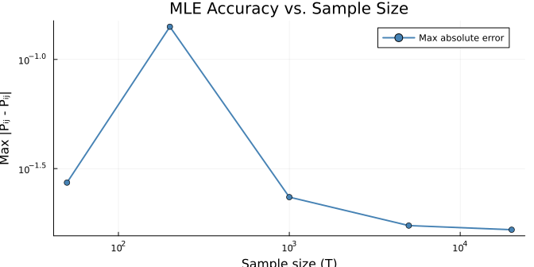

```julia
plot(sample_sizes, errors, marker=:circle, linewidth=2,
     color=:steelblue, label="Max absolute error",
     xscale=:log10, yscale=:log10,
     title="MLE Accuracy vs. Sample Size", size=(700, 350))
xlabel!("Sample size (T)")
ylabel!("Max |P̂ᵢⱼ - Pᵢⱼ|")
```

## 7.5 The Log-Likelihood Function

### 7.5.1 Computing the Log-Likelihood

It is often useful to evaluate the log-likelihood directly—for example, to compare competing models or to perform numerical optimization. Here is a function that computes the log-likelihood of a state sequence given a transition matrix:

```julia
"""
    loglikelihood_mc(P, s)

Compute the log-likelihood of state sequence `s` given transition matrix `P`.

# Arguments
- `P`: an `n × n` transition matrix
- `s`: a vector of state indices

# Returns
- The log-likelihood (a scalar)
"""
function loglikelihood_mc(P, s)
    ll = 0.0
    for t in 2:length(s)
        ll += log(P[s[t-1], s[t]])
    end
    return ll
end
```

```
Main.Notebook.loglikelihood_mc
```

### 7.5.2 Comparing Log-Likelihoods

The MLE should achieve a higher log-likelihood than any other valid transition matrix. Let us verify this by comparing three candidates: our MLE $\hat{P}$, the true $P$, and a naive matrix with equal transition probabilities:

```julia
P_wrong = [0.5 0.5;
           0.5 0.5]

println("Log-likelihood at P̂ (MLE):    ", round(loglikelihood_mc(P̂, s), digits=2))
println("Log-likelihood at true P:      ", round(loglikelihood_mc(P, s), digits=2))
println("Log-likelihood at P = 0.5 I:   ", round(loglikelihood_mc(P_wrong, s), digits=2))
```

```
Log-likelihood at P̂ (MLE):    -1984.67
Log-likelihood at true P:      -1984.77
Log-likelihood at P = 0.5 I:   -3465.04
```

As expected, the MLE achieves the highest log-likelihood. The true $P$ comes in a close second (it would match the MLE exactly with infinite data), while the naive equal-probability matrix does substantially worse because it ignores the persistence in the data.

### 7.5.3 Visualizing the Likelihood Surface

For our $2 \times 2$ transition matrix, the constraint that rows sum to one means there are only two free parameters: $P_{11}$ (the probability of staying in a boom) and $P_{22}$ (the probability of staying in a recession). We can visualize the log-likelihood as a function of these two parameters:

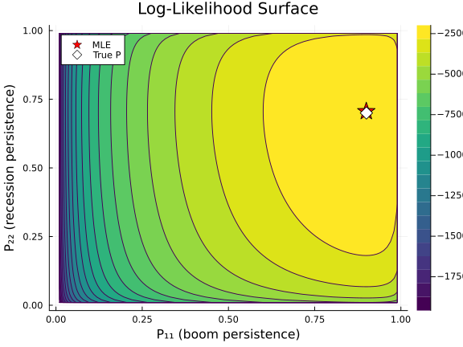

```julia
p11_grid = 0.01:0.01:0.99
p22_grid = 0.01:0.01:0.99

ll_surface = [loglikelihood_mc([p11 1-p11; 1-p22 p22], s)
              for p11 in p11_grid, p22 in p22_grid]

contourf(p11_grid, p22_grid, ll_surface',
         xlabel="P₁₁ (boom persistence)",
         ylabel="P₂₂ (recession persistence)",
         title="Log-Likelihood Surface",
         color=:viridis, size=(600, 450), levels=20)
scatter!([P̂[1,1]], [P̂[2,2]], marker=:star5, markersize=12,
         color=:red, label="MLE")
scatter!([P[1,1]], [P[2,2]], marker=:diamond, markersize=8,
         color=:white, label="True P")
```

The contour plot shows that the log-likelihood surface has a single, well-defined peak near the true parameter values. The MLE (red star) sits right at this peak, while the true $P$ (white diamond) is very close by. The concavity of the surface confirms that the maximum is unique—there is no ambiguity about the best-fitting transition matrix.

## 7.6 Numerical MLE with `Optim.jl`

### 7.6.1 Why Numerical Optimization?

For the simple case of estimating a transition matrix, we derived a closed-form MLE. But many econometric models do not have closed-form solutions. In those cases, we need to use **numerical optimization** to find the parameter values that maximize the likelihood. Julia’s `Optim.jl` package provides a variety of optimization algorithms for this purpose.

Even when a closed form exists, it is good practice to verify it numerically. Let us use `Optim.jl` to find the MLE and confirm that it matches our closed-form answer.

```julia
using Optim
```

### 7.6.2 Setting Up the Objective Function

For numerical optimization, we need to express the problem as minimizing a function of a parameter vector. Since `Optim.jl` minimizes by default, we minimize the **negative** log-likelihood (which is equivalent to maximizing the log-likelihood).

We parameterize the $2 \times 2$ transition matrix by the two free parameters $\theta = (P_{11}, P_{22})$ and reconstruct the full matrix inside the objective function:

```julia
function neg_loglik(θ, s)
    p11, p22 = θ
    P_candidate = [p11 1-p11;
                   1-p22  p22]
    return -loglikelihood_mc(P_candidate, s)
end
```

```
neg_loglik (generic function with 1 method)
```

### 7.6.3 Running the Optimizer

Since probabilities must lie between 0 and 1, we use **box-constrained optimization** with the `Fminbox` wrapper around the L-BFGS algorithm. We start from a uniform initial guess of $\theta_0 = (0.5, 0.5)$:

```julia
θ₀ = [0.5, 0.5]                          # Initial guess
result = optimize(θ -> neg_loglik(θ, s),  # Objective function
                  [0.01, 0.01],           # Lower bounds
                  [0.99, 0.99],           # Upper bounds
                  θ₀,                     # Starting point
                  Fminbox(LBFGS()))        # Bounded L-BFGS algorithm
```

```
 * Status: success

 * Candidate solution
    Final objective value:     1.984667e+03

 * Found with
    Algorithm:     Fminbox with L-BFGS

 * Convergence measures
    |x - x'|               = 0.00e+00 ≤ 0.0e+00
    |x - x'|/|x'|          = 0.00e+00 ≤ 0.0e+00
    |f(x) - f(x')|         = 0.00e+00 ≤ 0.0e+00
    |f(x) - f(x')|/|f(x')| = 0.00e+00 ≤ 0.0e+00
    |g(x)|                 = 9.57e-07 ≰ 1.0e-08

 * Work counters
    Seconds run:   12  (vs limit Inf)
    Iterations:    141
    f(x) calls:    85737
    ∇f(x) calls:   85737
```

The `optimize` function returns a results object containing the minimizer, the minimum function value, and convergence information.

### 7.6.4 Extracting and Comparing Results

We extract the optimal parameters and reconstruct the estimated transition matrix:

```julia
θ_mle = Optim.minimizer(result)
P̂_optim = [θ_mle[1] 1-θ_mle[1];
            1-θ_mle[2]  θ_mle[2]]

println("Optim MLE:")
display(P̂_optim)
println("\nClosed-form MLE:")
display(P̂)
println("\nTrue P:")
display(P)
```

```
Optim MLE:

Closed-form MLE:

True P:
```

```
2×2 Matrix{Float64}:
 0.899678  0.100322
 0.294256  0.705744
```

```
2×2 Matrix{Float64}:
 0.899678  0.100322
 0.294256  0.705744
```

```
2×2 Matrix{Float64}:
 0.9  0.1
 0.3  0.7
```

The numerically optimized estimate should match the closed-form MLE to high precision. Any tiny differences are due to the optimizer’s convergence tolerance, not a fundamental disagreement.

**TipWhen to Use Numerical Optimization**

For transition matrices, the closed-form MLE is simpler and more efficient. But `Optim.jl` becomes essential when:

- The model has **no closed-form solution** (e.g., hidden Markov models, structural estimation).
- You want to impose **additional constraints** beyond row-summing-to-one.
- The likelihood involves **latent variables** or **complex functional forms**.

The pattern demonstrated here—define an objective function, choose an algorithm, extract the minimizer—is the same regardless of model complexity.

# 8 Multi-Step Transition Probabilities

## 8.1 The $k$-Step Transition Matrix

So far we have studied one-step transitions: the probability of moving from state $i$ to state $j$ in a single period is given by $P_{i,j}$. But many economic questions involve longer horizons. What is the probability that an economy currently in recession will be in an expansion five years from now? What is the distribution of states ten periods ahead?

The answer comes from a simple and elegant result: the **$k$-step transition matrix** is just the $k$-th power of $P$:

$$P^{(k)} = P^k$$

The entry $P^k_{i,j}$ gives the probability of going from state $i$ to state $j$ in **exactly** $k$ steps. The intuition is straightforward. To go from state $i$ to state $j$ in two steps, the chain must pass through some intermediate state $m$ after one step. The probability of this particular two-step path is $P_{i,m} \cdot P_{m,j}$. Summing over all possible intermediate states gives:

$$P^{(2)}_{i,j} = \sum_{m=1}^n P_{i,m} \cdot P_{m,j}$$

This is precisely the $(i,j)$ entry of the matrix product $P \cdot P = P^2$. The same logic extends inductively: $P^{(k)} = P^{k-1} \cdot P = P^k$.

## 8.2 Computing Multi-Step Transitions in Julia

In Julia, matrix powers are computed with the `^` operator, just as for scalars. Let us compute the two-step, ten-step, and hundred-step transition matrices for our business cycle model:

```julia
P^2     # 2-step transition matrix
```

```
2×2 Matrix{Float64}:
 0.84  0.16
 0.48  0.52
```

```julia
P^10    # 10-step transition matrix
```

```
2×2 Matrix{Float64}:
 0.751512  0.248488
 0.745465  0.254535
```

```julia
P^100   # 100-step transition matrix
```

```
2×2 Matrix{Float64}:
 0.75  0.25
 0.75  0.25
```

Notice something striking about $P^{100}$: both rows are nearly identical. This means that after 100 periods, the probability of being in each state is essentially the same **regardless of the starting state**. The chain has “forgotten” where it started. This is our first glimpse of the **stationary distribution**, which we will study in detail in the next section.

## 8.3 Example: Recession to Expansion in 5 Periods

Suppose the economy is currently in a recession (state 2). What is the probability of being in an expansion (state 1) in exactly 5 periods?

```julia
P5 = P^5
prob_rec_to_exp = P5[2, 1]
println("Probability of expansion in 5 periods, starting from recession: ", round(prob_rec_to_exp, digits=4))
```

```
Probability of expansion in 5 periods, starting from recession: 0.6917
```

We can also compute the entire distribution over states 5 periods ahead, starting from a recession:

```julia
P5[2, :]   # Full distribution in 5 periods, starting from recession
```

```
2-element Vector{Float64}:
 0.69168
 0.3083199999999999
```

## 8.4 Convergence of $P^k$

As $k$ grows, the rows of $P^k$ converge to a common vector. We can visualize this convergence by plotting $P^k_{1,1}$ (the probability of being in an expansion $k$ periods from now, given that we start in an expansion) and $P^k_{2,1}$ (the same probability starting from a recession):

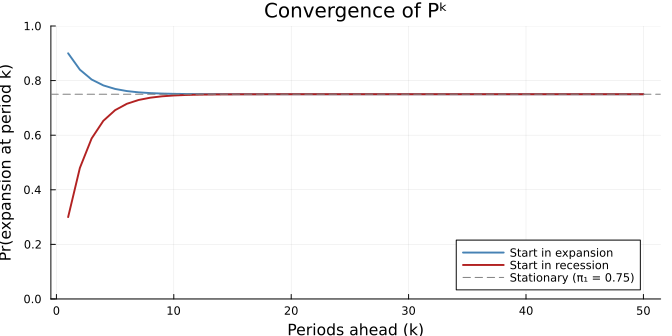

```julia
K = 50
prob_exp_from_exp = [(P^k)[1, 1] for k in 1:K]
prob_exp_from_rec = [(P^k)[2, 1] for k in 1:K]

plot(1:K, prob_exp_from_exp, linewidth=2, color=:steelblue,
     label="Start in expansion", title="Convergence of Pᵏ",
     size=(700, 350), ylims=(0, 1))
plot!(1:K, prob_exp_from_rec, linewidth=2, color=:firebrick,
      label="Start in recession")
hline!([0.75], color=:gray, linestyle=:dash, label="Stationary (π₁ = 0.75)")
xlabel!("Periods ahead (k)")
ylabel!("Pr(expansion at period k)")
```

Both curves converge to the same value—approximately 0.75—regardless of the starting state. This limiting probability is the stationary distribution’s weight on the expansion state. The convergence is rapid: after about 15 periods, the two curves are virtually indistinguishable. The speed of this convergence is governed by the second-largest eigenvalue of $P$, which we will examine later.

## 8.5 Verifying Multi-Step Probabilities by Simulation

We can verify the multi-step transition probabilities using Monte Carlo simulation. The idea is simple: start many independent chains in state 2 (recession), run each for 5 periods, and count how many end up in state 1 (expansion). The fraction should converge to $P^5_{2,1}$:

```julia
N_sims = 50_000
k_steps = 5
count_expansion = 0

for i in 1:N_sims
    s_sim, _ = simulateMarkov(P, ḡ, k_steps + 1; s₁=2)   # Start in recession
    if s_sim[end] == 1
        count_expansion += 1
    end
end

prob_sim = count_expansion / N_sims
println("Simulated Pr(expansion in $k_steps steps | start in recession): ", round(prob_sim, digits=4))
println("Theoretical P⁵[2,1]: ", round(P5[2, 1], digits=4))
```

```
Simulated Pr(expansion in 5 steps | start in recession): 0.6896
Theoretical P⁵[2,1]: 0.6917
```

The simulated probability closely matches the theoretical value, confirming that matrix powers correctly compute multi-step transition probabilities.

# 9 Stationary Distributions

## 9.1 Definition

A probability vector $\pi = (\pi_1, \pi_2, \ldots, \pi_n)'$ is a **stationary distribution** (or **invariant distribution**) of a Markov chain with transition matrix $P$ if it satisfies two conditions:

1. **Invariance**: $\pi' P = \pi'$ — applying the transition matrix leaves the distribution unchanged.
2. **Valid probability**: $\sum_{i=1}^n \pi_i = 1$ and $\pi_i \geq 0$ for all $i$.

The interpretation is powerful: if the chain starts with the distribution $\pi$ over states, then after one period the distribution is still $\pi$. And therefore after two periods it is still $\pi$, and so on forever. The distribution is **self-perpetuating**—the chain has reached a kind of statistical equilibrium.

## 9.2 Economic Interpretation

The stationary distribution has a natural economic interpretation: $\pi_i$ is the **long-run fraction of time** the economy spends in state $i$. If $\pi_1 = 0.75$ for the expansion state in our business cycle model, that means the economy spends about 75% of its time in expansion and 25% in recession in the long run. This is a crucial quantity for economic analysis—it tells us the “average” state of the economy, the frequency of recessions, and the typical duration of business cycles.

## 9.3 Finding $\pi$ as an Eigenvector Problem

The invariance condition $\pi' P = \pi'$ can be rewritten as $P' \pi = \pi$. This says that $\pi$ is an **eigenvector** of the transpose $P'$ with **eigenvalue 1**. We can therefore find the stationary distribution by computing the eigendecomposition of $P'$ and extracting the eigenvector corresponding to eigenvalue 1.

A fundamental theorem in the theory of Markov chains (the Perron–Frobenius theorem) guarantees that every transition matrix has 1 as its largest eigenvalue, and the corresponding eigenvector can be chosen to have all non-negative entries. After normalizing so the entries sum to 1, we obtain $\pi$.

```julia
vals, vecs = eigen(P')
println("Eigenvalues of P': ", vals)
```

```
Eigenvalues of P': [0.6, 1.0]
```

We need the eigenvector corresponding to eigenvalue 1. Since eigenvalues are not always returned in a predictable order, we find the index of the eigenvalue closest to 1:

```julia
idx = argmin(abs.(vals .- 1.0))          # Index of eigenvalue closest to 1
π_raw = real.(vecs[:, idx])               # Extract the corresponding eigenvector
π_stat = π_raw ./ sum(π_raw)              # Normalize to sum to 1
println("Stationary distribution: π = ", round.(π_stat, digits=4))
```

```
Stationary distribution: π = [0.75, 0.25]
```

## 9.4 Alternative: Solving the Linear System

An equivalent approach is to solve the linear system $(P' - I)\pi = 0$ subject to $\sum_i \pi_i = 1$. We replace one of the equations in $(P' - I)\pi = 0$ (which are linearly dependent) with the normalization constraint:

```julia
n = size(P, 1)
A = copy(P') - I                        # P'π = π  ⟹  (P' - I)π = 0
A[end, :] .= 1.0                        # Replace last equation with Σπᵢ = 1
b = zeros(n)
b[end] = 1.0                            # Right-hand side: last entry = 1

π_linear = A \ b                         # Solve the system
println("Stationary distribution (linear system): π = ", round.(π_linear, digits=4))
```

```
Stationary distribution (linear system): π = [0.75, 0.25]
```

Both methods give the same answer. The eigenvector approach is more general and extends naturally to larger state spaces, while the linear system approach is slightly more direct for small problems.

## 9.5 Example: Business Cycle Stationary Distribution

For our business cycle model with $P = \begin{pmatrix} 0.9 & 0.1 \\ 0.3 & 0.7 \end{pmatrix}$, the stationary distribution tells us the long-run composition of the economy:

```julia
println("Long-run probability of expansion: ", round(π_stat[1], digits=4))
println("Long-run probability of recession: ", round(π_stat[2], digits=4))
println("Long-run average growth rate: ", round(dot(π_stat, ḡ), digits=4))
```

```
Long-run probability of expansion: 0.75
Long-run probability of recession: 0.25
Long-run average growth rate: 0.02
```

The economy spends 75% of its time in expansion and 25% in recession. The long-run average growth rate is the probability-weighted average of the two growth rates—a single number that summarizes the economy’s typical performance.

A related quantity is the **expected duration** of each state. If the economy is currently in state $i$, the probability of staying in state $i$ next period is $P_{ii}$. The number of consecutive periods in state $i$ follows a geometric distribution, so the expected duration is $1 / (1 - P_{ii})$:

```julia
dur_expansion = 1 / (1 - P[1, 1])
dur_recession = 1 / (1 - P[2, 2])
println("Expected duration of an expansion: ", round(dur_expansion, digits=1), " periods")
println("Expected duration of a recession:  ", round(dur_recession, digits=1), " periods")
```

```
Expected duration of an expansion: 10.0 periods
Expected duration of a recession:  3.3 periods
```

Expansions last on average 10 periods and recessions about 3.3 periods. This is consistent with the NBER business cycle dating for the U.S., where expansions have historically been much longer than recessions.

## 9.6 Verification by Simulation

We can verify the stationary distribution by running a very long simulation and comparing the empirical state frequencies to $\pi$. By running the chain for many periods, the fraction of time spent in each state should converge to the stationary probabilities:

```julia
T_long = 100_000
s_long, g_long = simulateMarkov(P, ḡ, T_long)

freq_expansion = sum(s_long .== 1) / T_long
freq_recession = sum(s_long .== 2) / T_long

println("Simulated frequency of expansion: ", round(freq_expansion, digits=4))
println("Simulated frequency of recession: ", round(freq_recession, digits=4))
println("Stationary distribution:           π = ", round.(π_stat, digits=4))
```

```
Simulated frequency of expansion: 0.7441
Simulated frequency of recession: 0.2559
Stationary distribution:           π = [0.75, 0.25]
```

The simulated frequencies and the analytical stationary distribution should be very close, confirming our calculations. The small discrepancy shrinks as `T_long` increases.

**ImportantExistence and Uniqueness**

Not every Markov chain has a unique stationary distribution. Two conditions guarantee existence and uniqueness:

1. **Irreducibility**: it is possible to reach every state from every other state (possibly in multiple steps). In our business cycle model, you can go from expansion to recession and back, so the chain is irreducible.
2. **Aperiodicity**: the chain does not cycle deterministically through a fixed sequence of states. Since both $P_{1,1} > 0$ and $P_{2,2} > 0$ (the chain can stay in any state), it is aperiodic.

If a Markov chain is both irreducible and aperiodic, it has exactly one stationary distribution, and $P^k$ converges to a matrix with identical rows equal to $\pi'$ as $k \to \infty$. If either condition fails, the long-run behavior can be more complex: multiple stationary distributions may exist, or the chain may cycle without settling down.

# 10 The Ergodic Theorem

## 10.1 Statement

The stationary distribution tells us the long-run fraction of time the chain spends in each state. The **Ergodic Theorem** formalizes this intuition and extends it to functions of the state. For an irreducible, aperiodic Markov chain with stationary distribution $\pi$, the time average of any function $f$ converges almost surely to its expectation under $\pi$:

$$\frac{1}{T}\sum_{t=1}^{T} f(X_t) \xrightarrow{a.s.} \sum_{i=1}^{n} \pi_i \, f(\bar x_i) \quad \text{as } T \to \infty$$

In words: if you run the chain long enough and average the values of $f$ along the path, the result converges to the probability-weighted average of $f$ under the stationary distribution. **Time averages equal ensemble averages.**

## 10.2 Intuition

Why does this work? Because an irreducible, aperiodic chain visits each state $i$ with long-run frequency $\pi_i$. So in a sample of $T$ periods, state $i$ appears approximately $\pi_i \cdot T$ times. The time average of $f$ is therefore approximately:

$$\frac{1}{T}\sum_{t=1}^{T} f(X_t) \approx \sum_{i=1}^{n} \frac{\pi_i T}{T} f(\bar x_i) = \sum_{i=1}^{n} \pi_i \, f(\bar x_i)$$

This is the same result we would get by drawing $T$ **independent** samples from $\pi$ and averaging—even though the Markov chain samples are **dependent** (each depends on the previous one). The ergodic theorem says that, for the purpose of computing long-run averages, this dependence does not matter.

**TipConnection to the Law of Large Numbers**

The ergodic theorem is the Markov chain generalization of the **Law of Large Numbers** (LLN). The classical LLN says that the average of i.i.d. random variables converges to their common mean. The ergodic theorem extends this to **dependent** sequences generated by a Markov chain. The i.i.d. case is actually a special case: an i.i.d. sequence is a Markov chain where every row of $P$ is identical (the next state does not depend on the current state at all).

## 10.3 The Theoretical Foundation for Monte Carlo Simulation

The ergodic theorem is the theoretical justification for the Monte Carlo simulations we have been running throughout these notes. Every time we simulated a long chain and computed a sample average—to verify expected values, conditional expectations, or state frequencies—we were implicitly relying on the ergodic theorem. It guarantees that our simulation-based estimates converge to the true values as the simulation length grows.

## 10.4 Example: Long-Run Average Growth Rate

Let us use the ergodic theorem to compute the long-run average GDP growth rate. The theoretical value, using the stationary distribution, is:

$$\bar g_{\infty} = \sum_{i=1}^{n} \pi_i \, \bar g_i = \pi_1 \cdot 0.03 + \pi_2 \cdot (-0.01)$$

```julia
g_longrun_theory = dot(π_stat, ḡ)
println("Ergodic theorem (theoretical): long-run average growth = ", round(g_longrun_theory, digits=4))
```

```
Ergodic theorem (theoretical): long-run average growth = 0.02
```

Now let us compare this to the time average from our long simulation:

```julia
g_longrun_sim = mean(g_long)
println("Monte Carlo (simulated):       long-run average growth = ", round(g_longrun_sim, digits=4))
println("Difference: ", round(abs(g_longrun_theory - g_longrun_sim), digits=6))
```

```
Monte Carlo (simulated):       long-run average growth = 0.0198
Difference: 0.000235
```

The two values are nearly identical, confirming the ergodic theorem in action. The small remaining difference is sampling variability, which shrinks as $T$ increases.

## 10.5 Beyond Averages: Long-Run Variance and Recession Probability

The ergodic theorem applies to **any** function of the state, not just the identity. This means we can use it to compute any long-run statistic. For example, let $f(X_t) = X_t^2$. Then the ergodic theorem gives us $\frac{1}{T}\sum X_t^2 \to \sum \pi_i \bar x_i^2$, which lets us compute the long-run variance of growth:

```julia
# Long-run second moment
E_g2_theory = dot(π_stat, ḡ.^2)

# Long-run variance = E[g²] - (E[g])²
var_theory = E_g2_theory - g_longrun_theory^2
var_sim = var(g_long)

println("Theoretical long-run variance of growth: ", round(var_theory, digits=6))
println("Simulated variance of growth:            ", round(var_sim, digits=6))
```

```
Theoretical long-run variance of growth: 0.0003
Simulated variance of growth:            0.000305
```

We can also compute the long-run probability of negative growth by setting $f(X_t) = \mathbf{1}(X_t < 0)$—the indicator function for recession. The ergodic theorem tells us this converges to $\sum \pi_i \mathbf{1}(\bar x_i < 0) = \pi_2$, since only state 2 has negative growth:

```julia
# Fraction of periods with negative growth
frac_negative_sim = mean(g_long .< 0)
println("Simulated fraction of negative growth periods: ", round(frac_negative_sim, digits=4))
println("Theoretical (π₂):                              ", round(π_stat[2], digits=4))
```

```
Simulated fraction of negative growth periods: 0.2559
Theoretical (π₂):                              0.25
```

This illustrates the power of the ergodic theorem: a single long simulation provides consistent estimates of **all** long-run statistics simultaneously.

## 10.6 Convergence of the Time Average

How quickly does the time average converge to the ergodic limit? We can track the running average as $T$ grows to see the convergence in real time:

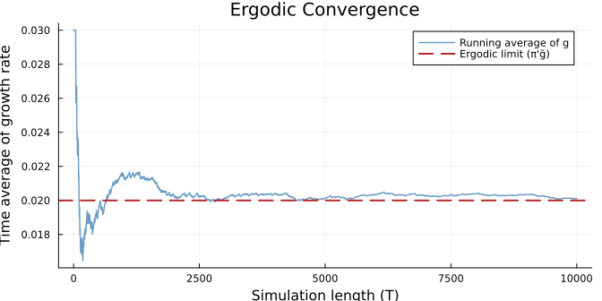

```julia
running_avg = cumsum(g_long) ./ (1:T_long)

plot(running_avg[1:10_000], linewidth=1.5, color=:steelblue,
     label="Running average of g", title="Ergodic Convergence",
     size=(700, 350), alpha=0.8)
hline!([g_longrun_theory], color=:firebrick, linewidth=2, linestyle=:dash,
       label="Ergodic limit (π'ḡ)")
xlabel!("Simulation length (T)")
ylabel!("Time average of growth rate")
```

The running average fluctuates considerably in the early periods when the sample is small, but it steadily settles down toward the ergodic limit (dashed red line) as $T$ grows. By $T = 5{,}000$ or so, the running average has essentially stabilized.

## 10.7 How Long Must the Chain Run?

The ergodic theorem guarantees convergence, but it does not tell us **how fast** convergence occurs. In practice, this matters: if you need a simulation of length $T = 10{,}000{,}000$ to get a reliable estimate, that is much more costly than if $T = 1{,}000$ suffices.

The convergence rate depends on how quickly the chain “mixes”—that is, how rapidly it forgets its initial state. A chain that switches between states frequently mixes fast, while a chain that lingers in each state for long stretches mixes slowly. The next section makes this precise by connecting the mixing speed to the eigenvalues of $P$.

# 11 Mixing Time and Convergence Speed

## 11.1 The Role of Eigenvalues

How fast does $P^k$ converge to the stationary distribution? The answer lies in the **eigenvalues** of $P$. Every $n \times n$ transition matrix has $n$ eigenvalues $\lambda_1, \lambda_2, \ldots, \lambda_n$. For an irreducible, aperiodic chain, the largest eigenvalue is always $\lambda_1 = 1$ (corresponding to the stationary distribution). All other eigenvalues satisfy $|\lambda_i| < 1$.

The convergence rate is controlled by the **second-largest eigenvalue in absolute value**, which we denote $|\lambda_2|$. The distance between $P^k$ and the limiting matrix shrinks approximately like $|\lambda_2|^k$:

$$\| P^k - \mathbf{1}\pi' \| \approx C \cdot |\lambda_2|^k$$

where $\mathbf{1}\pi'$ is the matrix with every row equal to $\pi'$ and $C$ is a constant. The smaller $|\lambda_2|$ is, the faster the convergence.

## 11.2 Computing Eigenvalues in Julia

Let us compute the eigenvalues of our business cycle transition matrix:

```julia
λ = eigvals(P)
println("Eigenvalues of P: ", round.(λ, digits=4))
println("Second-largest eigenvalue: |λ₂| = ", round(abs(λ[1]), digits=4))
```

```
Eigenvalues of P: [0.6, 1.0]
Second-largest eigenvalue: |λ₂| = 0.6
```

```julia
λ_sorted = sort(abs.(λ), rev=true)
println("Eigenvalues sorted by magnitude: ", round.(λ_sorted, digits=4))
println("Spectral gap: 1 - |λ₂| = ", round(1 - λ_sorted[2], digits=4))
```

```
Eigenvalues sorted by magnitude: [1.0, 0.6]
Spectral gap: 1 - |λ₂| = 0.4
```

The **spectral gap** $1 - |\lambda_2|$ measures how much “room” there is between the dominant eigenvalue and the rest. A larger spectral gap means faster mixing.

## 11.3 Comparing Fast and Slow Mixing

To build intuition, let us compare two extreme parameterizations. A **slowly mixing** chain has high persistence—entries close to the identity matrix—meaning the economy rarely switches states. A **fast mixing** chain has entries closer to uniform, meaning switches happen frequently:

```julia
P_slow = [0.99 0.01;    # Very persistent: states almost never switch
          0.01 0.99]

P_fast = [0.5 0.5;      # No persistence: uniform transitions
          0.5 0.5]

λ_slow = sort(abs.(eigvals(P_slow)), rev=true)
λ_fast = sort(abs.(eigvals(P_fast)), rev=true)

println("Slow chain: |λ₂| = ", round(λ_slow[2], digits=4), "  spectral gap = ", round(1 - λ_slow[2], digits=4))
println("Fast chain: |λ₂| = ", round(λ_fast[2], digits=4), "  spectral gap = ", round(1 - λ_fast[2], digits=4))
```

```
Slow chain: |λ₂| = 0.98  spectral gap = 0.02
Fast chain: |λ₂| = 0.0  spectral gap = 1.0
```

The slowly mixing chain has $|\lambda_2| = 0.98$, very close to 1, so convergence is glacial. The fast mixing chain has $|\lambda_2| = 0$, so convergence is instant—after just one step, the chain has already reached the stationary distribution.

## 11.4 Visualizing Convergence Speed

We can see the difference dramatically by plotting how quickly $P^k_{1,1}$ converges to the stationary value for each parameterization:

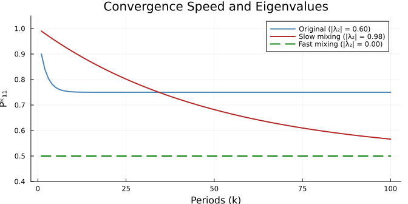

```julia
K = 100
conv_original = [(P^k)[1,1] for k in 1:K]
conv_slow = [(P_slow^k)[1,1] for k in 1:K]
conv_fast = [(P_fast^k)[1,1] for k in 1:K]

plot(1:K, conv_original, linewidth=2, color=:steelblue,
     label="Original (|λ₂| = 0.60)", title="Convergence Speed and Eigenvalues",
     size=(700, 350), ylims=(0.4, 1.05))
plot!(1:K, conv_slow, linewidth=2, color=:firebrick,
      label="Slow mixing (|λ₂| = 0.98)")
plot!(1:K, conv_fast, linewidth=2, color=:green,
      label="Fast mixing (|λ₂| = 0.00)", linestyle=:dash)
xlabel!("Periods (k)")
ylabel!("Pᵏ₁₁")
```

## 11.5 Economic Interpretation

The second-largest eigenvalue has a direct economic interpretation: it measures the **persistence** of the Markov chain. A chain with $|\lambda_2|$ close to 1 represents an economy where states are highly persistent—recessions last a long time and expansions last a long time. A chain with $|\lambda_2|$ close to 0 represents an economy where the current state provides little information about the future.

For our business cycle model, $|\lambda_2| = 0.60$ indicates moderate persistence: the economy’s current state is informative about the near future but not the distant future. After about 15 periods, the current state is essentially irrelevant for forecasting.

**WarningPractical Implications for Simulation**

The mixing time has important consequences for Monte Carlo simulation:

- **Burn-in period**: When simulating a Markov chain, the early observations are influenced by the arbitrary initial state. A common practice is to discard an initial “burn-in” period of several mixing times before collecting data. For a chain with $|\lambda_2| = 0.98$, the burn-in must be very long.
- **Simulation length**: The ergodic theorem guarantees convergence of time averages, but slowly mixing chains require much longer simulations to achieve a given level of accuracy. If $|\lambda_2|$ is close to 1, you may need $T$ in the hundreds of thousands or millions.
- **Effective sample size**: Even with $T$ observations from a slowly mixing chain, the effective number of independent observations is much smaller than $T$ because consecutive observations are highly correlated. The effective sample size is roughly $T \cdot (1 - |\lambda_2|) / (1 + |\lambda_2|)$.

When calibrating economic models, always check the eigenvalues of your transition matrix. If $|\lambda_2|$ is close to 1, plan for longer simulations and larger burn-in periods.

# 12 Summary

In these notes we covered the theory and Julia implementation of finite state Markov chains:

**Discrete random variables** are the foundation. They are defined by a vector of possible values $\bar x$ and a probability vector $p$, and can be simulated in Julia using `Categorical` from the `Distributions` package.

**Finite state Markov chains** extend discrete random variables by allowing the probability distribution to depend on the current state through a **transition matrix** $P$. The entry $P_{i,j}$ gives the probability of moving from state $i$ to state $j$. The Markov property—that only the current state matters, not the history—is what makes these models tractable.

**Simulation** is straightforward once you have a `drawDiscrete` function: at each time step, extract the appropriate row of $P$ and draw the next state. Pre-allocating arrays before the simulation loop is important for performance.

**Expected values** of discrete random variables are dot products: $\mathbb{E}[X] = p \cdot \bar X$. **Conditional expectations** for Markov chains are also dot products, one for each row of $P$:

$$\mathbb{E}[X_{t+1} | X_t = \bar X_i] = P_{i,\cdot} \cdot \bar X$$

Stacking these gives the elegant matrix formula $P\bar X$.

**Monte Carlo verification** provides a way to check analytical formulas: simulate the process many times and compare sample averages to theoretical values. As the number of simulations grows, the empirical and theoretical values converge.

**Maximum likelihood estimation** gives us a principled way to estimate the transition matrix from observed data. The MLE has an elegant closed form: $\hat{P}_{ij} = n_{ij} / n_{i\cdot}$, the fraction of transitions from state $i$ that go to state $j$. This estimator is consistent and asymptotically efficient.

**Numerical optimization** with `Optim.jl` provides a general-purpose alternative when closed-form solutions are unavailable. The pattern of defining a negative log-likelihood, choosing an algorithm, and extracting the minimizer carries over to far more complex models.

**Multi-step transition probabilities** are computed by matrix powers: $P^k_{i,j}$ gives the probability of going from state $i$ to state $j$ in $k$ steps. As $k \to \infty$, the rows of $P^k$ converge to the stationary distribution.

**Stationary distributions** satisfy $\pi' P = \pi'$ and represent the long-run fraction of time the chain spends in each state. They can be found as eigenvectors of $P'$ or by solving a linear system. Existence and uniqueness require irreducibility and aperiodicity.

**The Ergodic Theorem** guarantees that time averages converge to ensemble averages: $\frac{1}{T}\sum f(X_t) \to \sum \pi_i f(\bar x_i)$. This is the theoretical foundation for Monte Carlo simulation with Markov chains.

**Mixing time** is governed by the second-largest eigenvalue $|\lambda_2|$ of the transition matrix. Chains with $|\lambda_2|$ close to 1 converge slowly and require longer simulations, while chains with small $|\lambda_2|$ mix rapidly.

**ImportantKey Things to Remember**

- A Markov chain is defined by values $\bar x$ and a transition matrix $P$.
- Row $i$ of $P$ gives the conditional distribution of the next state given current state $i$.
- The vector of conditional expectations equals $P\bar X$.
- The MLE of $P_{ij}$ is the fraction of transitions from $i$ to $j$: $\hat{P}_{ij} = n_{ij}/n_{i\cdot}$.
- The $k$-step transition matrix is $P^k$; as $k \to \infty$ it converges to $\mathbf{1}\pi'$.
- The stationary distribution $\pi$ is the left eigenvector of $P$ with eigenvalue 1.
- The Ergodic Theorem: time averages equal expectations under $\pi$ for irreducible, aperiodic chains.
- The second-largest eigenvalue $|\lambda_2|$ controls convergence speed; check it before running long simulations.
- Use `Categorical` from `Distributions` to draw from discrete distributions.
- Use `Optim.jl` for numerical MLE when no closed form exists.
- Pre-allocate arrays with `zeros(T)` for efficient simulation.
- Monte Carlo simulation is a powerful tool for verifying analytical results.

With these tools in hand, you are ready to apply Markov chains to economic models such as the McCall search model, the Diamond–Mortensen–Pissarides matching model, and the Kydland–Prescott real business cycle model.